# Two disadvantages of the ESRI File Geodatabase

Xuezhi Cang Email: xuezhicang@gmail.com Website: https://xuezhicang.com/

*Two disadvantages: 1) the FGBD does not fully support the multiprocessing library; 2) I/O ofFGDBis slow if you have a **big** set of data.*

A File GeoDataBase (FGDB) is a collection of files in a folder on disk that can store, query, and manage both spatial and nonspatial data. (https://desktop.arcgis.com/en/arcmap/10.3/manage-data/administer-file-gdbs/file-geodatabases.htm#:~:text=A%20file%20geodatabase%20is%20a,Feature%20class)

Using feature class and raster dataset in the FGDB, instead of using shapefile and grid data in the ordinary oler, is recomanded by ESRI. The main reasons are: 1) there is a 2 GB size limit for any shapefile component file; and 2) the name length of grid file must be smaller than 13 characters.

However, the GDB is not always better than the ordinoray folder **when we deal with a large amount of files**. The example is shown as below.

## 1. Our task

We have a global Martian flow accumulation raster data, which is generated from the gloabl Martian DEM data, and a global Martian watersheds vector data consisting of a lot of polygons. Our task is to 1) split the watershed polygons to single files based on their ID, 2) extract the flow accumulation raster data to single raster files by using each watershed, and 3) export the watershed boundary to CSV file, whose watershed area is labeled as 1 and outlet cell is labeled as 2.

## 2. Original Strategy

The SearchCursor (https://pro.arcgis.com/en/pro-app/latest/arcpy/data-access/searchcursor-class.htm) is used to select and paste each small watershed polygon from the global watersheds data. Then, every small flow accumulation area is extracted and stored in the GDB. At last, every CSV is generated from the corresponding flow accumulation file.

Since the watershed feature class has a lot of watersheds, this program is extremely SLOW. It needs more than five hours to process 2,000 watershed polygons. The total number of watersheds are more than 15,000, so this speed is NOT ACCEPTDABLE.

My code:

```
import numpy as np
import arcpy
from arcpy.sa import *
import os
arcpy.env.overwriteOutput = True

def func(input_list):

    ws_feature = input_list[1]

    featureLayer = 'layer{0}'.format(input_list[0])

    # select and paste the polygon to the folder
    arcpy.management.MakeFeatureLayer(ws_feature,featureLayer,"""id = {0}""".format((input_list[0])))
    arcpy.CopyFeatures_management(featureLayer, input_list[4] + "ws_"+str(input_list[0]))


    # extract the small flow accumulation area to folder
    flow_acc_ExtractByMask = ExtractByMask(Raster(flow_acc_data), i[4] + "ws_"+str(i[0]))
    flow_acc_ExtractByMask.save(i[5] +"fa_"+ str(i[0]))

    # expert the CSV
    facc_max_value = arcpy.GetRasterProperties_management(flow_acc_ExtractByMask, "MAXIMUM")
    outCon = Con(Raster(flow_acc_ExtractByMask) == int(facc_max_value[0]), 1)
    outCon2 = Con(IsNull(outCon),1,2)
    outCon3 = Con(Raster(flow_acc_ExtractByMask)>=0,outCon2,-1)

    arr = arcpy.RasterToNumPyArray(outCon3,nodata_to_value = -1)
    temp = np.array(arr)
    np.savetxt(input_list[6] +"wsmat_"+ str(input_list[0])+".csv", temp, delimiter=",")

    arcpy.Delete_management(featureLayer)
    return

if __name__ == '__main__':

    # parameter setting:
    # working place
    working_folder = # my working folder
    # create GDB to store the watershed shapefile
    ws_shp = working_folder + "ws_shp.gdb//"
    # create GDB to store the watershed shapefile
    facc_raster = working_folder + "fa_ra.gdb//"
    # create folder to store the watershed CSV file
    ws_csv = working_folder + "ws_csv//"
    # watershed feature class (including more than 15,000 polygons)
    ws_feature =  #watersheds polygons
    # Martian global flow accumulation data
    flow_acc_data = #a large raster data

    # Create a list of ID. The rand value is not greater than the random threshold
    ws_feature_rows = arcpy.SearchCursor(ws_feature)
    ws_feature_IDs = \
    [[ row.getValue('ID'),\
      ws_feature,\
      flow_dir_data,\
      flow_acc_data,\
      ws_shp,\
      facc_raster,\
      ws_csv] \
      for row in ws_feature_rows]


    # for-loop
    for i in ws_feature_IDs:
        func(i)
```

## 3.Improved Strategy

### 3.1Parallel Computing

Since the tasks of function in the for-loop are similar and do not depend on each other. The parallel computing should be a good idea to accelerate our program's speed!

A sample Python parallel computing code (from https://docs.python.org/3/library/multiprocessing.html) is shownn as below:

#### Multiprocessing

```
from multiprocessing import Pool

def f(x):
    return x*x

if __name__ == '__main__':
    with Pool(5) as p:
        print(p.map(f, [1, 2, 3]))
```

Sicne the juptyter node book is not very friendly with multiprocessing. The output is not printed here. You can copy and paste the code to your own Python IDE. The result should be [1, 4, 9]

#### 3.1.1 Problem 1

Following the structure of the example, I build my multiprocessing version program. Unfortunately, it does not work. The reason is that we cannot use pool function to write files to the FGDB. The explanation is shown as below:

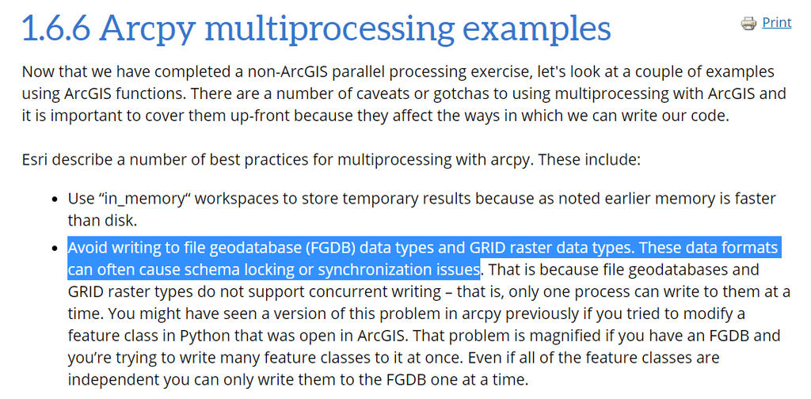

https://www.e-education.psu.edu/geog489/node/2261

#### 3.1.2 Solution for Problem 1

The shapefile and grid raster are writen to the **ordinary folder** by using the pool function. It greatly accelerates the computing speed.

#### 3.1.3 Problem 2

In my program, the small flow accumulation area is extracted by the extract-by-mask funtion (see: https://pro.arcgis.com/en/pro-app/latest/tool-reference/spatial-analyst/extract-by-mask.htm). When the extract-by-mask funtion is applied to the global flow accumulation raster file, it may report error (code: 999999). This error occurrs randomly, but frequentlly. The possible reason is that the extract-by-mask function needs to lock the global flow accumulation file to prevent other core's visit, and then causes the crash. (I hope that I make a good guess! If you know the real reason, please let me know)

#### 3.1.4 Solution for Problem 2

To solve this problem, I have to use a for-loop to extract the small flow accumulation area by using every single watershed file and use the pool function to split the watershed polygons and export the CSV files (I know it is awkward, but it works at least.)

After solving the two problems, my code are shown as bwlow:

```
import multiprocessing
import numpy as np
import arcpy
from arcpy.sa import *
import time
import os
arcpy.env.overwriteOutput = True

def split_polygons(input_list):

    ws_feature = input_list[1]
    featureLayer = 'layer{0}'.format(input_list[0])

    # select and paste the polygon to the folder
    arcpy.management.MakeFeatureLayer(ws_feature,featureLayer,"""id = {0}""".format((input_list[0])))
    arcpy.CopyFeatures_management(featureLayer, input_list[4] + "ws_"+str(input_list[0]))
    arcpy.Delete_management(featureLayer)
    return

def create_watershed_CSV(input_list):
    # export the CSV
    flow_acc_ExtractByMask = input_list[5] + "fa_" + str(input_list[0])
    facc_max_value = arcpy.GetRasterProperties_management(flow_acc_ExtractByMask, "MAXIMUM")
    outCon = Con(Raster(flow_acc_ExtractByMask) == int(facc_max_value[0]), 1)
    outCon2 = Con(IsNull(outCon),1,2)
    outCon3 = Con(Raster(flow_acc_ExtractByMask)>=0,outCon2,-1)

    arr = arcpy.RasterToNumPyArray(outCon3,nodata_to_value = -1)
    temp = np.array(arr)
    np.savetxt(input_list[6] +"wsmat_"+ str(input_list[0])+".csv", temp, delimiter=",")

    return

if __name__ == '__main__':

    # parameter setting:
    # working place
    working_folder =
    # create folder to store the watershed shapefile
    ws_shp = working_folder + "ws_shp//"
    # create folder to store the watershed shapefile
    facc_raster = working_folder + "fa_ra//"
    # create folder to store the watershed CSV file
    ws_csv = working_folder + "ws_csv//"
    # watershed feature class (including more than 15,000 polygons)
    ws_feature =
    # Martian global flow accumulation data
    flow_acc_data =


    # Create a list of ID. The rand value is not greater than the random threshold
    ws_feature_rows = arcpy.SearchCursor(ws_feature)

    ws_feature_IDs =\
    [[ row.getValue('ID'),ws_feature,flow_dir_data,flow_acc_data,ws_shp,facc_raster,ws_csv] \
     for row in ws_feature_rows ]


    # this part extract the watersher shapefile to the folder.
    pool = multiprocessing.Pool()
    result = pool.map(split_polygons, ws_feature_IDs)


    # extract the facc raster by mask
    for i in ws_feature_IDs:
        # extract the flow accumulation area by using watershed polygon
        flow_acc_ExtractByMask = \
        ExtractByMask(Raster(flow_acc_data), i[4] + "ws_"+str(i[0]) + ".shp")
        flow_acc_ExtractByMask.save(i[5] +"fa_"+ str(i[0]))

    # extract the watershed csv files
    result = pool.map(create_watershed_CSV, ws_feature_IDs)

    pool.close()
    pool.join()
```

### 3.2 I/O speed

As I mentioned in the **Problem 2 section**, I use a for-loop to extract the flow accumulation area. If the global flow accumulation data is in the FGDB, the program takes a lot of time. If the flow accumulation is converted to TIFF file and stored in an ordinary folder, the processing speed will be improved greatly. I think that the reason is the I/O for the GDB is much much slower than the I/O for the ordinary folder.

The code for the comparsion is shown as below:

```
start_time = time.time()
# extract the facc raster by mask
for i in ws_feature_IDs:
    # extract the csv file and save it to folder
    # flow_acc_data is the global flow accumulation data
    flow_acc_ExtractByMask = ExtractByMask(Raster(flow_acc_data), i[4] + "ws_"+str(i[0]) + ".shp")
    flow_acc_ExtractByMask.save(i[5] +"fa_"+ str(i[0]))
end_time = time.time()
print("used time(in seconds): " + str(end_time - start_time))
```

To simplify the process, I only extract 10 flow accumulation files from the global flow accumulation file.

If the global flow accumulation is stored in the **GDB**, it takes **20.77s** for 10 watersheds.

If the global flow accumulation is stored in the **ordinary folder**, it takes **5.47s** for 10 watersheds.

Considering that we will process more than 15,000 watershed polygons, we need to wait a lot of time if the GDB is used here.

## 4. Summary

Although the GDB has a lot of advantages over the ordinary folder, we should use the ordinary folder to store our files (shapefiles, TIFF, etc.) if we want to use multiprocessing library to speed up our program.